# Solcast API — PVPMC 2026 Workshop

**Getting solar resource data programmatically with the Solcast Python SDK**

*Thursday 14 May 2026 · PVPMC Workshop, Albuquerque (NM)*

This notebook demonstrates four key data-retrieval workflows using the [Solcast API Python SDK](https://solcast.github.io/solcast-api-python-sdk/):

| Module | Method | What it returns |
| --- | --- | --- |
| `solcast.tmy` | `radiation_and_weather()` | Typical Meteorological Year — 8 760-record hourly dataset |
| `solcast.historic` | `radiation_and_weather()` | Satellite-derived actuals from 2007 to -7 days at up to 5-minute resolution |
| `solcast.live` | `radiation_and_weather()` | Satellite-derived actuals for -7 days to -5 minutes |
| `solcast.forecast` | `radiation_and_weather()` | Irradiance and weather forecasts up to 14 days ahead |

**SDK documentation:** https://solcast.github.io/solcast-api-python-sdk/  
**API documentation:** https://docs.solcast.com.au/

### Before you start

1. Sign up for a [Solcast API key](https://toolkit.solcast.com.au/register).
2. Set it as an environment variable:
   - Windows: `set SOLCAST_API_KEY=your-key`
   - Mac/Linux: `export SOLCAST_API_KEY=your-key`
3. Run each cell in order — the cells build on each other.

## 1. Setup & Configuration

```python
import os
import pandas as pd
import matplotlib.pyplot as plt
import matplotlib.ticker as mticker

# --- API key ---
# Option A: environment variable (recommended)
#   Windows:   set SOLCAST_API_KEY=your-key
#   Mac/Linux: export SOLCAST_API_KEY=your-key
# Option B: paste your key directly in the string below
API_KEY = os.environ.get("SOLCAST_API_KEY", "YOUR_KEY_HERE")

if API_KEY == "YOUR_KEY_HERE":
    print("WARNING: No API key set. Set the SOLCAST_API_KEY environment variable or paste your key above.")
else:
    print("API key found — ready to go.")
```

```
API key found — ready to go.
```

## 2. Location Selection

We will use the **workshop venue in Albuquerque, New Mexico** as our example site — the same location used in the SolarFarmer notebook, so the two can be used together end-to-end.

| Parameter | Value |
| --- | --- |
| Latitude | 35.10 °N |
| Longitude | −106.67 °E |

> **Tip:** The Solcast SDK includes a set of [unmetered locations](https://docs.solcast.com.au/#unmetered-locations) for development and testing — API calls to these coordinates don't count against your quota.

```python
# --- Site coordinates ---
# Workshop venue: Hotel Albuquerque, Albuquerque NM — same site as the SolarFarmer notebook
LATITUDE  = 35.10
LONGITUDE = -106.67

# Unmetered locations are safe for development — calls won't consume API quota
# Uncomment the lines below to use Fort Peck instead:
# from solcast.unmetered_locations import UNMETERED_LOCATIONS
# site = UNMETERED_LOCATIONS['Fort Peck']
# LATITUDE, LONGITUDE = site['latitude'], site['longitude']

print(f"Site: {LATITUDE}°N, {LONGITUDE}°E")
```

```
Site: 35.1°N, -106.67°E
```

## 3. Available Weather Parameters

The `radiation_and_weather` endpoint exposes a broad set of meteorological variables.  
Pass any subset as a list (or comma-separated string) via `output_parameters`:

**Irradiance**

| Parameter | Units | Description |
| --- | --- | --- |
| `ghi` | W/m² | Global Horizontal Irradiance |
| `ghi10` | W/m² | GHI — 10th percentile (cloudier than expected) |
| `ghi90` | W/m² | GHI — 90th percentile (less cloudy than expected) |
| `dhi` | W/m² | Diffuse Horizontal Irradiance |
| `dhi10` | W/m² | DHI — 10th percentile |
| `dhi90` | W/m² | DHI — 90th percentile |
| `dni` | W/m² | Direct Normal Irradiance |
| `dni10` | W/m² | DNI — 10th percentile |
| `dni90` | W/m² | DNI — 90th percentile |
| `gti` | W/m² | Global Tilted Irradiance (tilted / tracking surface) |
| `gti10` | W/m² | GTI — 10th percentile |
| `gti90` | W/m² | GTI — 90th percentile |
| `clearsky_ghi` | W/m² | GHI under clear-sky conditions |
| `clearsky_dhi` | W/m² | DHI under clear-sky conditions |
| `clearsky_dni` | W/m² | DNI under clear-sky conditions |
| `clearsky_gti` | W/m² | GTI under clear-sky conditions |
| `cloud_opacity` | % | Cloud attenuation of incoming sunlight (0 = clear, 100 = fully opaque) |
| `cloud_opacity10` | % | Cloud opacity — 10th percentile clearness |
| `cloud_opacity90` | % | Cloud opacity — 90th percentile clearness |

**Temperature & Humidity**

| Parameter | Units | Description |
| --- | --- | --- |
| `air_temp` | °C | Air temperature at 2 m |
| `min_air_temp` | °C | Daily minimum air temperature at 2 m |
| `max_air_temp` | °C | Daily maximum air temperature at 2 m |
| `dewpoint_temp` | °C | Dewpoint temperature at 2 m |
| `relative_humidity` | % | Relative humidity at 2 m |

**Wind**

| Parameter | Units | Description |
| --- | --- | --- |
| `wind_speed_10m` | m/s | Wind speed at 10 m |
| `wind_speed_100m` | m/s | Wind speed at 100 m |
| `wind_direction_10m` | ° | Wind direction at 10 m (0 = north, 270 = from west) |
| `wind_direction_100m` | ° | Wind direction at 100 m |
| `wind_gust` | m/s | Maximum wind gust at 10 m (3-second average) |

**Precipitation & Snow**

| Parameter | Units | Description |
| --- | --- | --- |
| `precipitation_rate` | mm/h | Average precipitation rate (not accumulated) |
| `snowfall_rate` | cm/h | Snowfall rate (depth of fresh snow per hour) |
| `snow_depth` | cm | Physical snow pack depth on the ground |
| `snow_water_equivalent` | cm | Snow depth liquid-water equivalent |
| `snow_soiling_ground` | % | DC production loss from snow on ground-mounted modules |
| `snow_soiling_rooftop` | % | DC production loss from snow on rooftop modules |

**Atmospheric & Air Quality**

| Parameter | Units | Description |
| --- | --- | --- |
| `surface_pressure` | hPa | Air pressure at surface level |
| `precipitable_water` | kg/m² | Integrated water vapour column |
| `albedo` | fraction | Daytime average surface reflectivity (0–1) |
| `pm10` | μg/m³ | Particulate matter ≤ 10 μm |
| `pm2.5` | μg/m³ | Particulate matter ≤ 2.5 μm |
| `cape` | J/kg | Convective Available Potential Energy (thunderstorm indicator) |

**Sun Position & Classification**

| Parameter | Units | Description |
| --- | --- | --- |
| `azimuth` | ° | Solar azimuth (−180 to 180; −90 = east, 0 = north, 90 = west) |
| `zenith` | ° | Solar zenith angle (90° at sunrise/sunset, 0° overhead) |
| `weather_type` | string | Simple categorisation of weather conditions |

```python
# Standard parameter set used across TMY, historic and live endpoints
WEATHER_PARAMETERS = [
    'air_temp', 'albedo', 'ghi', 'dhi', 'precipitable_water',
    'precipitation_rate', 'relative_humidity', 'surface_pressure',
    'snow_depth', 'snow_soiling_ground', 'wind_speed_10m',
    'wind_gust', 'pm10', 'pm2.5', 'cloud_opacity',
]

print(f"Requesting {len(WEATHER_PARAMETERS)} parameters: {', '.join(WEATHER_PARAMETERS)}")
```

```
Requesting 15 parameters: air_temp, albedo, ghi, dhi, precipitable_water, precipitation_rate, relative_humidity, surface_pressure, snow_depth, snow_soiling_ground, wind_speed_10m, wind_gust, pm10, pm2.5, cloud_opacity
```

## 4. Typical Meteorological Year (TMY) — `tmy.radiation_and_weather()`

A TMY is a synthetic one-year hourly dataset derived from multiple years of satellite data.  
It captures the *typical* weather pattern for the location — the standard input for annual energy yield models.

The `tmy` module returns **8 760 hourly records** at 30-minute or 60-minute resolution.

```python
%%time
from solcast import tmy

tmy_data = tmy.radiation_and_weather(
    latitude=LATITUDE,
    longitude=LONGITUDE,
    output_parameters=WEATHER_PARAMETERS,
    api_key=API_KEY,
).to_pandas()

print(f"TMY dataset: {len(tmy_data)} records")
print(f"Date range:  {tmy_data.index[0]} → {tmy_data.index[-1]}")
tmy_data.head()
```

```
TMY dataset: 8760 records
Date range:  2059-01-01 01:00:00+00:00 → 2060-01-01 00:00:00+00:00
CPU times: total: 46.9 ms
Wall time: 12.4 s
```

| period_end | air_temp | cloud_opacity | dhi | ghi | precipitable_water | relative_humidity | surface_pressure | wind_speed_10m | albedo | snow_depth | precipitation_rate | snow_soiling_ground | wind_gust | pm10 | pm2.5 |
| --- | --- | --- | --- | --- | --- | --- | --- | --- | --- | --- | --- | --- | --- | --- | --- |
| 2059-01-01 01:00:00+00:00 | -1.3 | 0.0 | 0 | 0 | 1.8 | 28.6 | 879.4 | 3.5 | 0.22 | 1.5 | 0 | 3 | 7.6 | 5.6 | 2.6 |
| 2059-01-01 02:00:00+00:00 | -2.0 | 0.0 | 0 | 0 | 1.6 | 29.1 | 880.3 | 3.1 | 0.22 | 1.5 | 0 | 3 | 6.6 | 5.9 | 2.7 |
| 2059-01-01 03:00:00+00:00 | -4.4 | 0.0 | 0 | 0 | 1.5 | 32.1 | 881.3 | 3.0 | 0.22 | 1.5 | 0 | 3 | 5.8 | 6.4 | 2.8 |
| 2059-01-01 04:00:00+00:00 | -6.4 | 0.0 | 0 | 0 | 1.4 | 34.2 | 882.3 | 2.9 | 0.22 | 1.5 | 0 | 3 | 5.2 | 6.6 | 2.9 |
| 2059-01-01 05:00:00+00:00 | -6.6 | 0.0 | 0 | 0 | 1.4 | 33.0 | 883.3 | 2.6 | 0.22 | 1.5 | 0 | 3 | 4.7 | 6.3 | 2.9 |

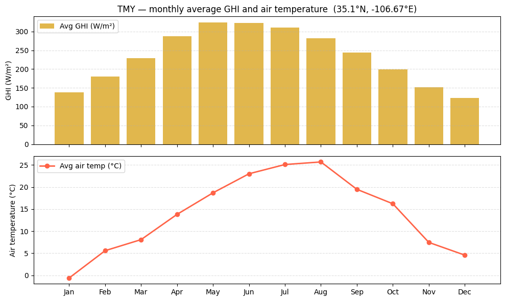

```python
# Monthly averages — quick sanity-check of the annual solar and temperature profile
MONTH_LABELS = ['Jan', 'Feb', 'Mar', 'Apr', 'May', 'Jun',
                'Jul', 'Aug', 'Sep', 'Oct', 'Nov', 'Dec']

tmy_monthly = (
    tmy_data[['ghi', 'air_temp']]
    .groupby(tmy_data.index.month)
    .mean()
)
tmy_monthly.index = MONTH_LABELS

fig, (ax1, ax2) = plt.subplots(2, 1, figsize=(10, 6), sharex=True)

ax1.bar(tmy_monthly.index, tmy_monthly['ghi'], color='goldenrod', alpha=0.8, label='Avg GHI (W/m²)')
ax1.set_ylabel('GHI (W/m²)')
ax1.set_title(f'TMY — monthly average GHI and air temperature  ({LATITUDE}°N, {LONGITUDE}°E)')
ax1.legend(loc='upper left')
ax1.grid(axis='y', linestyle='--', alpha=0.4)

ax2.plot(tmy_monthly.index, tmy_monthly['air_temp'], 'o-', color='tomato', linewidth=2, label='Avg air temp (°C)')
ax2.set_ylabel('Air temperature (°C)')
ax2.legend(loc='upper left')
ax2.grid(axis='y', linestyle='--', alpha=0.4)

plt.tight_layout()
plt.show()
```

## 5. Historic Data — `historic.radiation_and_weather()`

The `historic` endpoint provides **satellite-derived actuals** from 2007 to seven days ago at up to 5-minute resolution.  
Data is immutable and quality-controlled — ideal for resource studies, model validation, and gap-filling.

Key parameters:

| Parameter | Example | Notes |
| --- | --- | --- |
| `start` | `'2024-07-01T00:00'` | ISO-8601 timestamp (UTC) |
| `duration` | `'P7D'` | ISO-8601 duration — up to 31 days per call |
| `period` | `'PT30M'` | Time step: `PT5M`, `PT30M`, or `PT60M` |

> **Note:** Each call counts as one API request, regardless of the time window requested.

```python
%%time
from solcast import historic

historic_data = historic.radiation_and_weather(
    latitude=LATITUDE,
    longitude=LONGITUDE,
    start='2024-07-01T00:00',
    duration='P7D',      # 7 days of data
    period='PT30M',      # 30-minute resolution
    output_parameters=WEATHER_PARAMETERS,
    api_key=API_KEY,
).to_pandas()

print(f"Historic dataset: {len(historic_data)} records")
print(f"Date range:       {historic_data.index[0]} → {historic_data.index[-1]}")
historic_data.head()
```

```
Historic dataset: 336 records
Date range:       2024-07-01 00:30:00+00:00 → 2024-07-08 00:00:00+00:00
CPU times: total: 0 ns
Wall time: 1.6 s
```

| period_end | air_temp | albedo | cloud_opacity | dhi | ghi | precipitable_water | precipitation_rate | relative_humidity | surface_pressure | snow_depth | snow_soiling_ground | wind_speed_10m | wind_gust | pm10 | pm2.5 |
| --- | --- | --- | --- | --- | --- | --- | --- | --- | --- | --- | --- | --- | --- | --- | --- |
| 2024-07-01 00:30:00+00:00 | 31 | 0.19 | 13.4 | 138 | 308 | 31.4 | 0.0 | 27.7 | 875.3 | 0 | 0 | 3.7 | 5.6 | 10.7 | 5.1 |
| 2024-07-01 01:00:00+00:00 | 31 | 0.19 | 11.3 | 98 | 226 | 32.7 | 0.0 | 27.3 | 875.6 | 0 | 0 | 4.5 | 5.7 | 10.8 | 5.1 |
| 2024-07-01 01:30:00+00:00 | 30 | 0.19 | 21.6 | 75 | 118 | 33.5 | 0.0 | 28.9 | 875.8 | 0 | 0 | 4.8 | 5.9 | 10.9 | 5.2 |
| 2024-07-01 02:00:00+00:00 | 29 | 0.19 | 7.0 | 39 | 64 | 33.8 | 0.0 | 32.8 | 875.9 | 0 | 0 | 4.6 | 6.3 | 11.1 | 5.3 |
| 2024-07-01 02:30:00+00:00 | 28 | 0.19 | 9.7 | 8 | 10 | 34.0 | 0.0 | 36.5 | 876.1 | 0 | 0 | 4.1 | 6.6 | 11.2 | 5.4 |

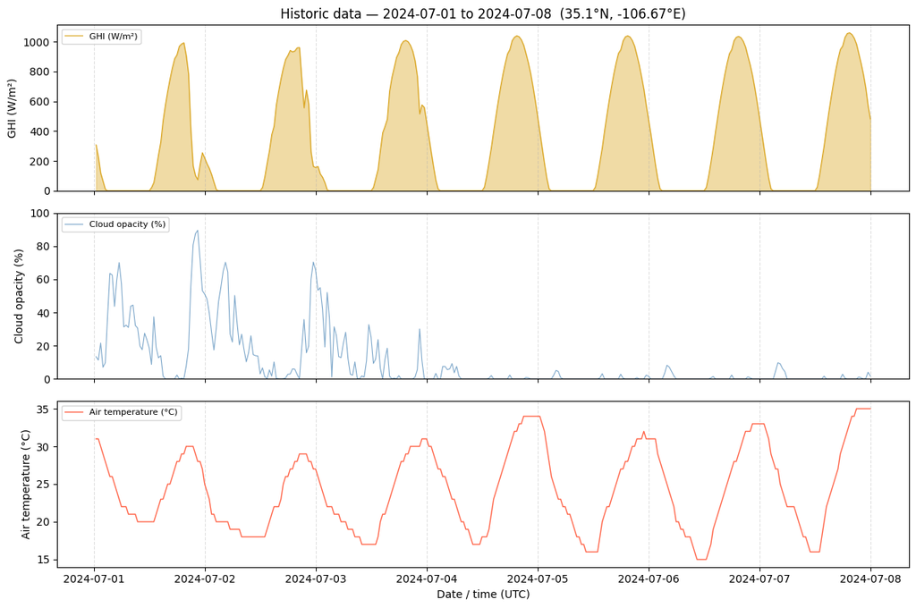

```python
fig, axes = plt.subplots(3, 1, figsize=(12, 8), sharex=True)

axes[0].fill_between(historic_data.index, historic_data['ghi'], alpha=0.4, color='goldenrod')
axes[0].plot(historic_data.index, historic_data['ghi'], color='goldenrod', linewidth=0.8, label='GHI (W/m²)')
axes[0].set_ylabel('GHI (W/m²)')
axes[0].set_ylim(bottom=0)
axes[0].set_title(
    f"Historic data — {historic_data.index[0].date()} to {historic_data.index[-1].date()}  "
    f"({LATITUDE}°N, {LONGITUDE}°E)"
)
axes[0].legend(loc='upper left', fontsize=8)

axes[1].plot(historic_data.index, historic_data['cloud_opacity'], color='steelblue',
             linewidth=0.8, alpha=0.7, label='Cloud opacity (%)')
axes[1].set_ylabel('Cloud opacity (%)')
axes[1].set_ylim(0, 100)
axes[1].legend(loc='upper left', fontsize=8)

axes[2].plot(historic_data.index, historic_data['air_temp'], color='tomato', linewidth=1, label='Air temperature (°C)')
axes[2].set_ylabel('Air temperature (°C)')
axes[2].set_xlabel('Date / time (UTC)')
axes[2].legend(loc='upper left', fontsize=8)

for ax in axes:
    ax.grid(axis='x', linestyle='--', alpha=0.4)

plt.tight_layout()
plt.show()
```

## 6. Live Data — `live.radiation_and_weather()`

The `live` endpoint provides **near-real-time** observations continuously updated as satellite imagery is processed.  
It covers the past few days up to the present moment — useful for monitoring dashboards and nowcasting.

Additional parameters available when requesting plane-of-array irradiance:

| Parameter | Example | Notes |
| --- | --- | --- |
| `tilt` | `23` | Module tilt in degrees (0 = horizontal) |
| `azimuth` | `150` | Azimuth in degrees (0 = north, 180 = south) |
| `hours` | `24 * 5` | How many hours back from now to retrieve |
| `period` | `'PT5M'` | Time step: `PT5M` or `PT30M` |

```python
%%time
from solcast import live

live_data = live.radiation_and_weather(
    latitude=LATITUDE,
    longitude=LONGITUDE,
    output_parameters='ghi,air_temp,weather_type',
    period='PT5M',    # 5-minute resolution
    hours=24 * 5,     # last 5 days
    tilt=23,          # module tilt angle for GTI calculation
    azimuth=150,      # azimuth (0 = north, 180 = south)
    api_key=API_KEY,
).to_pandas()

print(f"Live dataset: {len(live_data)} records")
print(f"Date range:   {live_data.index[0]} → {live_data.index[-1]}")
live_data.head(15)
```

```
Live dataset: 1440 records
Date range:   2026-05-07 10:35:00+00:00 → 2026-05-02 10:40:00+00:00
CPU times: total: 0 ns
Wall time: 890 ms
```

| period_end | ghi | air_temp | weather_type |
| --- | --- | --- | --- |
| 2026-05-07 10:35:00+00:00 | 0 | 7 | CLEAR |
| 2026-05-07 10:30:00+00:00 | 0 | 7 | CLEAR |
| 2026-05-07 10:25:00+00:00 | 0 | 7 | CLEAR |
| 2026-05-07 10:20:00+00:00 | 0 | 7 | CLEAR |
| 2026-05-07 10:15:00+00:00 | 0 | 7 | CLEAR |
| 2026-05-07 10:10:00+00:00 | 0 | 7 | CLEAR |
| 2026-05-07 10:05:00+00:00 | 0 | 7 | CLEAR |
| 2026-05-07 10:00:00+00:00 | 0 | 7 | CLEAR |
| 2026-05-07 09:55:00+00:00 | 0 | 7 | CLEAR |
| 2026-05-07 09:50:00+00:00 | 0 | 7 | CLEAR |
| 2026-05-07 09:45:00+00:00 | 0 | 8 | CLEAR |
| 2026-05-07 09:40:00+00:00 | 0 | 8 | CLEAR |
| 2026-05-07 09:35:00+00:00 | 0 | 8 | CLEAR |
| 2026-05-07 09:30:00+00:00 | 0 | 8 | CLEAR |
| 2026-05-07 09:25:00+00:00 | 0 | 8 | CLEAR |

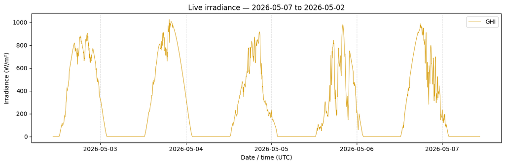

```python
fig, ax = plt.subplots(figsize=(12, 4))

ax.plot(live_data.index, live_data['ghi'], label='GHI', color='goldenrod', linewidth=0.8)
if 'gti' in live_data.columns:
    ax.plot(live_data.index, live_data['gti'], label='GTI (23°, az 150°)',
            color='darkorange', linewidth=0.8, alpha=0.8)

ax.set_ylabel('Irradiance (W/m²)')
ax.set_xlabel('Date / time (UTC)')
ax.set_title(f'Live irradiance — {live_data.index[0].date()} to {live_data.index[-1].date()}')
ax.legend()
ax.grid(axis='x', linestyle='--', alpha=0.4)
plt.tight_layout()
plt.show()
```

## 7. Forecast — `forecast.radiation_and_weather()`

The `forecast` endpoint returns irradiance and weather predictions **up to 14 days ahead**.  
Short-range forecasts (~4 h) are satellite-nowcast based; beyond that, numerical weather models take over.

| Parameter | Description |
| --- | --- |
| `ghi` | Global Horizontal Irradiance (W/m²) |
| `air_temp` | Air temperature (°C) |

```python
%%time
from solcast import forecast

FORECAST_PARAMETERS = ['ghi', 'ghi10', 'ghi90', 'air_temp']

forecast_data = forecast.radiation_and_weather(
    latitude=LATITUDE,
    longitude=LONGITUDE,
    output_parameters=FORECAST_PARAMETERS,
    period='PT30M',   # 30-minute resolution
    hours=48,         # next 48 hours
    api_key=API_KEY,
).to_pandas()

print(f"Forecast dataset: {len(forecast_data)} records")
print(f"Horizon:          {forecast_data.index[0]} → {forecast_data.index[-1]}")
forecast_data.head()
```

```
Forecast dataset: 97 records
Horizon:          2026-05-07 11:00:00+00:00 → 2026-05-09 11:00:00+00:00
CPU times: total: 0 ns
Wall time: 702 ms
```

| period_end | ghi | ghi10 | ghi90 | air_temp |
| --- | --- | --- | --- | --- |
| 2026-05-07 11:00:00+00:00 | 0 | 0 | 0 | 7 |
| 2026-05-07 11:30:00+00:00 | 0 | 0 | 0 | 6 |
| 2026-05-07 12:00:00+00:00 | 0 | 0 | 0 | 6 |
| 2026-05-07 12:30:00+00:00 | 7 | 7 | 7 | 6 |
| 2026-05-07 13:00:00+00:00 | 78 | 75 | 78 | 6 |

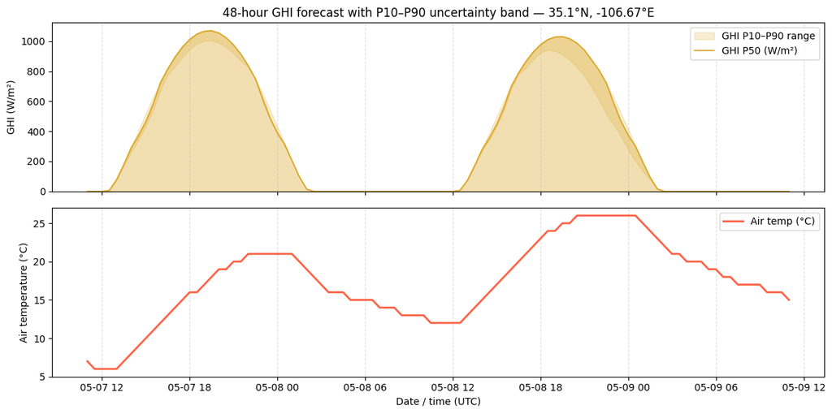

```python
fig, (ax1, ax2) = plt.subplots(2, 1, figsize=(12, 6), sharex=True)

# GHI panel — P10/P90 uncertainty band and P50 line
ax1.fill_between(
    forecast_data.index,
    forecast_data['ghi10'],
    forecast_data['ghi90'],
    alpha=0.2, color='goldenrod', label='GHI P10–P90 range',
)
ax1.fill_between(forecast_data.index, forecast_data['ghi'], alpha=0.35, color='goldenrod')
ax1.plot(forecast_data.index, forecast_data['ghi'], color='goldenrod', linewidth=1.2, label='GHI P50 (W/m²)')
ax1.set_ylabel('GHI (W/m²)')
ax1.set_ylim(bottom=0)
ax1.set_title(f'48-hour GHI forecast with P10–P90 uncertainty band — {LATITUDE}°N, {LONGITUDE}°E')
ax1.legend(loc='upper right')
ax1.grid(axis='x', linestyle='--', alpha=0.4)

# Air temperature panel
ax2.plot(forecast_data.index, forecast_data['air_temp'], color='tomato', linewidth=2, label='Air temp (°C)')
ax2.set_ylabel('Air temperature (°C)')
ax2.set_xlabel('Date / time (UTC)')
ax2.legend(loc='upper right')
ax2.grid(axis='x', linestyle='--', alpha=0.4)

plt.tight_layout()
plt.show()
```

## 8. Summary

You have now retrieved solar resource data via four Solcast endpoints:

| Module | Dataset | Primary use case |
| --- | --- | --- |
| `tmy` | 8760-record typical year | Annual energy yield modelling |
| `historic` | Satellite-derived actuals from 2007+ | Resource studies, backtest, gap-filling |
| `live` | Near-real-time observations | Monitoring |
| `forecast` | Up to 14 days ahead | Dispatch optimisation, short-term prediction |

## Next steps

**What to explore after the workshop:**

- Swap in your own site coordinates and re-run all cells
- Extend the parameter list to include any variables of interest to you
- Pass the TMY or any weather dataset to SolarFarmer API for a full or partial energy yield calculation
- Loop over multiple sites to build a portfolio comparison

**API documentation & support:**  
https://docs.solcast.com.au/

*Thank you for joining the DNV Green Data Products session at PVPMC 2026!*